# index

## Introducción

En esta exploración, voy a encontrar patrones y consistencias en las funciones racionales de la forma $f(x) = \frac{5}{(x-1)...(x-r)}$ incluyendo asíntotas horizontales, verticales, y oblicuas.

### Definiciones

- Asíntota: Línea recta que, prolongada indefinidamente, se acerca progresivamente a una curva sin llegar nunca a encontrarla. Puede ser horizontal, vertical, o oblicua. Estos son líneas paralelas al eje x, y, o ninguno, respectivamente.
- Función racional: Funcion de la forma $R(x) = \frac{P(x)}{Q(x)}$ donde $Q(x) \neq 0$

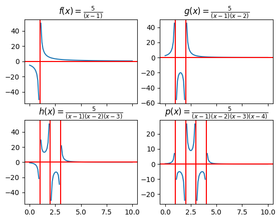

#### Asíntotas horizontales

En una función racional $R(x) = \frac{P(x)}{Q(x)}$, las asíntotas horizontales solo existen si el grado de $P(x)$ es menor o igual al grado de $Q(x)$. En las funciones que estamos analizando, puesto que el grado del numerador siempre es 0, al considerar a 5 como $(5)(x^0)$ y el grado del denominador siempre es por lo menos 1, podemos determinar que la asíntota horizontal de $R(x)$ siempre se encuentra en $y = 0$

#### Asíntotas verticales

En una función racional $R(x) = \frac{P(x)}{Q(x)}$, las asíntotas verticales existen en las raíces de $Q(x)$. Por lo tanto, dado a que $Q(x)$ siempre es una factorización de un polinomio en las funciones que estamos analizando, siempre van a existir tantas asíntotas verticales como hay factores lineales en el denominador, en cada solución del polinomio.

#### Asíntotas oblicuas

En una función racional $R(x) = \frac{P(x)}{Q(x)}$, las asíntotas oblicuas existen si el grado de $P(x)$ es mayor al grado de $Q(x)$. Como fue establecido anteriormente, en las funciones que estamos analizando, esto nunca ocurre, por lo que las funciones nunca tendrán asíntotas oblicuas.